# Reproducible Research: Peer Assessment 1

Luis Fernando Agottani

09/08/2019

## Loading and preprocessing the data

Verify if the filename has been downloaded/unzip yet. If not, download/unzip the file with the fileURL link.

```r
filename <- "repdata_data_activity.zip"

if (!file.exists(filename)){
  fileURL <- "https://d396qusza40orc.cloudfront.net/repdata%2Fdata%2Factivity.zip"
  download.file(fileURL, filename)
}
if (!file.exists("activity.csv")) {
  unzip(filename)
}
```

Reading data.csv.

```r
Act<- read.csv("activity.csv",
               head = TRUE, sep= ",")
```

Changing the Factor type of the column date to Date with as.Date.

```r
Act$date<- as.Date(Act$date)
```

## What is mean total number of steps taken per day?

Library Dplyr to work with “%>%”

```r
library(dplyr)
```

The total number of steps is the sum of all steps measured by day. The mean is the sum divided by the number of intervals..

```r
Act_Day<- Act %>%
  group_by(date) %>%
  summarise(steps = sum(steps))
```

## Including Plots

Ploting a histogram with the sum, mean and median of steps by day.

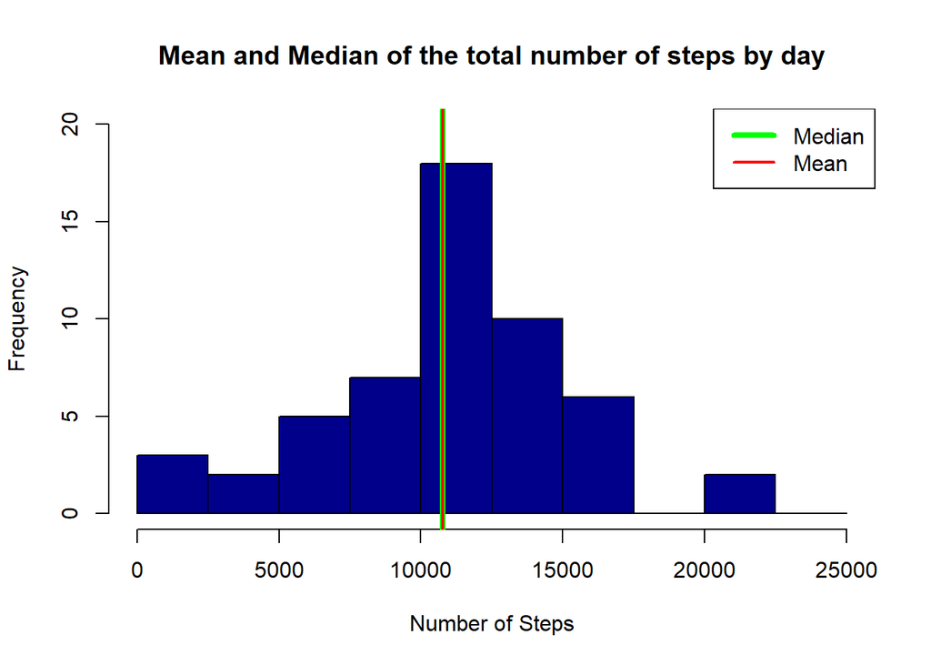

```r
hist(Act_Day$steps,
     breaks= seq(from=0, to=25000, by=2500),
     col="darkblue",
     border="black",
     xlab="Number of Steps",
     main="Mean and Median of the total number of steps by day",
     ylim=c(0, 20),
     xlim=c(0,25000))

abline(v=median(Act_Day$steps,
                na.rm=TRUE),
       col="green",
       lwd=4)

abline(v=mean(Act_Day$steps,
              na.rm=TRUE),
       col="red",lwd=2)

legend(x="topright", #subtitle postion
      c("Median","Mean"), #name of the subtitle
      col=c("green","red"), #colors
      lty=c(1,1), #line style
      lwd=c(4,2)) #line widht
```

## What is the average daily activity pattern?

The daily activity pattern is the mean of the number of steps of all days by interval.

```r
Act_Interval<- Act %>%
  group_by(interval) %>%
  summarise(steps = mean(steps,
                         na.rm=TRUE))
```

Ploting the Mean of steps of all days by Interval with the line plot.

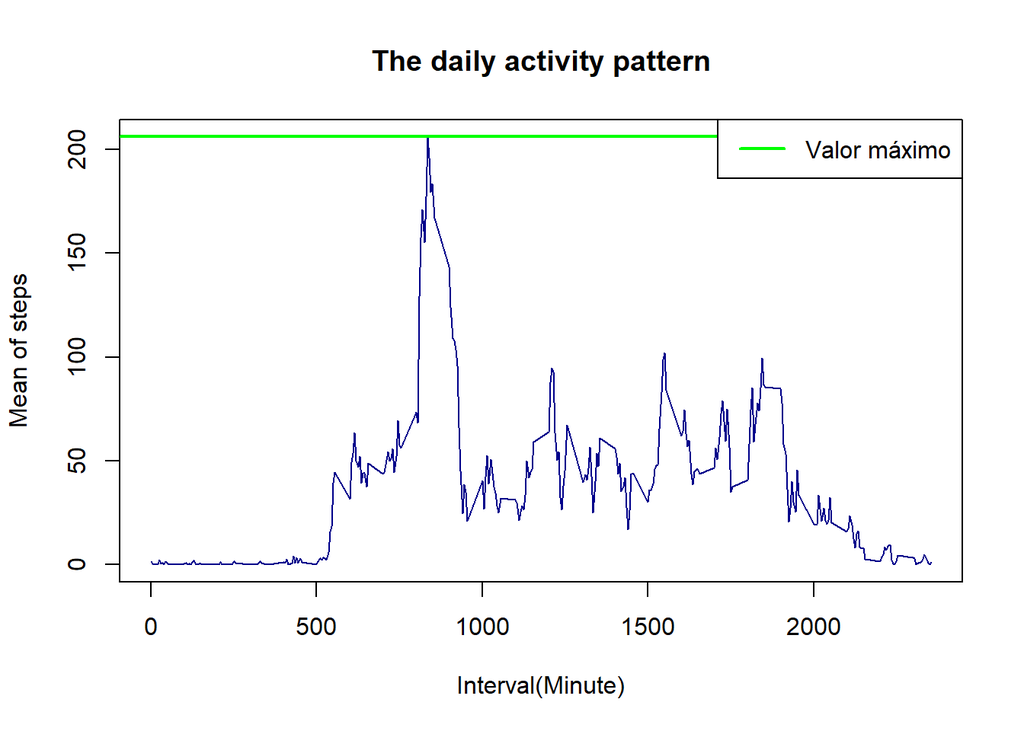

```r
plot(Act_Interval$interval,
     Act_Interval$steps,
     type="l",
     col="darkblue",
     xlab="Interval(Minute)",
     ylab="Mean of steps",
     main="The daily activity pattern")

abline(h=max(Act_Interval$steps),
       col="green",
       lwd=2)

legend(x="topright",
      "Valor máximo",
      col="green",
      lty=1,
      lwd=2)
```

## Imputing missing values

To represent the missing data and verify the number of the missing data in each column, a nice way to do it is with the package “mice” and “VIM”.

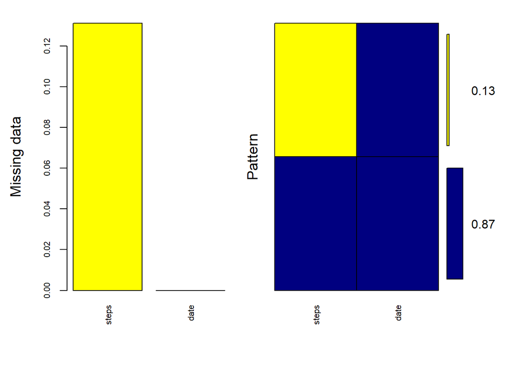

```
##
##  Variables sorted by number of missings:
##  Variable     Count
##     steps 0.1311475
##      date 0.0000000
```

```r
library(mice)
library(VIM)

mice_plot <- aggr(Act_Day,
                  col=c('navyblue','yellow'),
                  numbers=TRUE,
                  sortVars=TRUE,
                  labels=names(Act_Day),
                  cex.axis=.7,
                  gap=3,
                  ylab=c("Missing data","Pattern"))
```

The result show us that is a big amount, x>5%, of NA’s in the data, we have to take care to impute the a value that help us with accuracy.

With library “mice” and the pmm method, we will impute values to missing data.

```r
imputed_Data <- mice(Act,
                     m=5,
                     maxit = 50,
                     method = 'pmm',
                     seed = 500)
completeData <- complete(imputed_Data,2)

completeDataSum<- completeData %>%
  group_by(date) %>%
  summarise(steps = sum(steps))
```

Ploting the complete data.

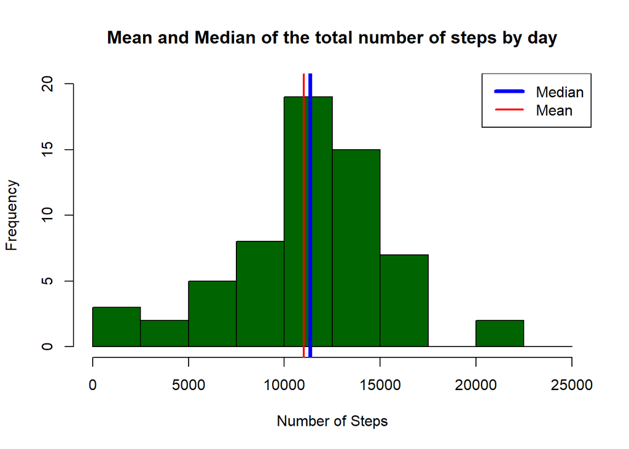

```r
hist(completeDataSum$steps,
     breaks= seq(from=0, to=25000, by=2500),
     col="darkgreen",
     border="black",
     xlab="Number of Steps",
     main="Mean and Median of the total number of steps by day",
     ylim=c(0, 20),
     xlim=c(0,25000))


abline(v=median(completeDataSum$steps,na.rm=TRUE),
       col="blue",
       lwd=4)

abline(v=mean(completeDataSum$steps,
              na.rm=TRUE),
       col="red",
       lwd=2)

legend(x="topright",
      c("Median","Mean"),
      col=c("blue","red"),
      lty=c(1,1),
      lwd=c(4,2))
```

As we can see, imputing values with de pmm method showed us a similar result comparing with the first part of the assignment. So, we can assume that imputing missing values did not impacted signifcally.

## Are there differences in activity patterns between weekdays and weekends?

```r
Act_days<- mutate(completeData,
                  days=weekdays(completeData$date))

Act_week<- mutate(Act_days,
                  weekpart=(ifelse(Act_days$days=="sábado"|Act_days$days=="domingo","weekend","weekday")))

Act_weekdays<- Act_week %>%
  group_by(interval,weekpart) %>%
  summarise(steps = mean(steps))
```

Ploting the comparassion between the parts of the week, “weekdays” and “weekend”, to see if have some pattern there.

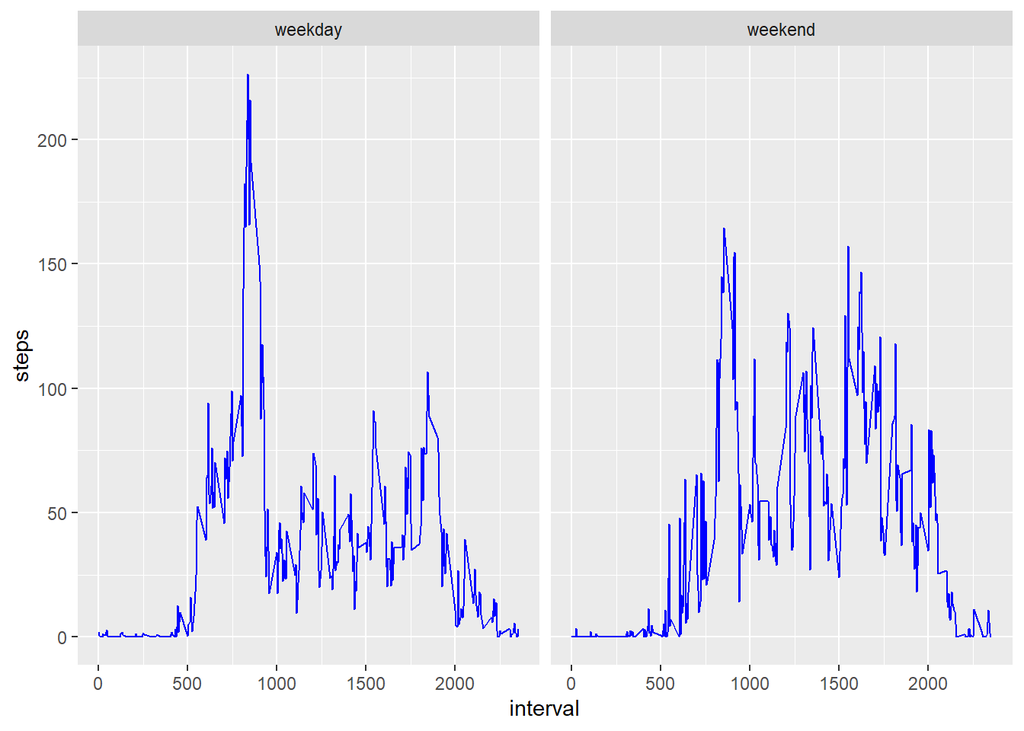

```r
library(ggplot2)

ggplot(aes(x=interval,y=steps),
       data=Act_weekdays)+
       geom_line(col="blue")+
       facet_wrap(~Act_weekdays$weekpart)
```